# 人工智慧- 進階課程 - 課程 26－Deep Learning- Single Shot MultiBox Detector - SSD -介紹 Part - 01 - Images Object Detection - 圖像 目標 檢測 - Python Tutorial

''' 人工智慧- 進階課程 A.I Tutorials - Advanced Course - Deep Learning 教程 ''' 05 - 深度學習 教程 課程 26 - Deep Learning- - Single Shot MultiBox Detector Introduction Part - 01 程式範例 - SSD - Images Object Detection - 圖像目標 檢測 ''' ''' >> 資料準備 >> 你我互動學習園地- 進階課程 Advanced Course >> https://interactiveuandmetutorialsac.weebly.com/ >> 你我互動學習園地 >> https://interactiveuandmetutorials.weebly.com/ >> Python 程式語言 設計 >> https://pythonprogrammingtutorials.weebly.com/ >> 目錄結構 : >> Deep Learning- 課程 26－Deep Learning- Single Shot MultiBox Detector - SSD -介紹 Part -01 -介紹 Images - 目標檢測.zip 檔案路徑/ ├── 課程 26－Deep Learning- Single Shot MultiBox Detector - SSD -介紹 Part -01 -介紹 Images - 目標檢測 .ipynb | ├── bounding_box_utils| | ├── __init__.py | └── bounding_box_utils.py ├── data_generator | ├─ data_augmentation_chain_constant_input_size.py | ├─ XXX | ├─ XXX | ├─ XXX | ├─ XXX X10 files | ├─ XXX | ├─ XXX | └── object_detection_2d_photometric_ops.py | ├── eval_utils | ├── __init__.py | ├── average_precision_evaluator.py | └── coco_utils.py | ├── keras_layers | ├── __init__.py | ├── keras_layer_AnchorBoxes.py | ├── keras_layer_DecodeDetections.py | ├── keras_layer_DecodeDetectionsFast.py | └── keras_layer_L2Normalization.py | ├── keras_loss_function | ├── __init__.py | └── keras_ssd_loss.py ├── misc_utils | ├── __init__.py | └── tensor_sampling_utils.py | ├── models | ├── __init__.py | ├── keras_ssd7.py | ├── keras_ssd300.py | └── keras_ssd512.py | ├── VGG_VOC0712_SSD_300x300_iter_120000.h5 ! ├── ssd_encoder_decoder | ├── __init__.py | ├── matching_utils.py | ├── ssd_input_encoder.py | └── ssd_output_decoder.py ! ├── training_summaries | ├── ssd300_pascal_07+12_loss_history | └── ssd300_pascal_07+12_training_summary.md | ├── datasets | └── VOCdevkit | └── VOC2007 | ├── Annotations | ├── ImageSets | | ├── Layout | | ├── Main | | └── Segmentation | ├── JPEGImages | ├── SegmentationClass | └── SegmentationObject | ├── examples | └── XXX.jpg ├── model.h5 | └── model1.h5 '''

- SSD Single Shot MultiBox Detector - Paper 論文參考
  - https://arxiv.org/pdf/1512.02325.pdf
- pierluigiferrari/ssd_keras
  - https://github.com/pierluigiferrari/ssd_keras

''' SSD - Single Shot MultiBox Detector - YoLo -> V3 版本以前 - 有個小逅病 - 對於小物件的偵測效果不佳 - 在 V3 時 - 提出方法改善 - SSD - 是怎麼 - 對於小物件的偵測 - 不會隨著網路層數越深變差 - 當網路層數越深 - 由於小物件 - 經過多次的 Convolution 迭代 - 經過越多層 - 能留下來的訊息就會越來越小 - 導致最後對於小物體的效果 , 不是很明顯. - SSD 的 網路架構 - 首先會先經過 VGG16 的 神經網路 - 接著加上一層 Layer Norm 與 一些 Convolution -> 加深網路 - 這 與 一般加深神經網路 -> 有什麼不一樣呢 ？ - 原來是最後要進行輸出時 - 並不會只取最後的輸出 - 而是會將在幾層卷積層的輸出合併起來, 一起來輸出 - 這樣越前面 - 的卷積層 -> 對小物件的訊息掌握度高 - 越後面 - 的卷基層 -> 也可以掌握大物件的訊息 - 分別將 l2Norm, Conv7, Conv8_2, Conv9_2, Conv10_2, Conv11_2 的輸出 - 輸入到 Mutlilayer '''

- SSD

[figure not shown]

- YoLoV1/YoLoV2/YoLoV3

[figure not shown]

- YoLov3

[figure not shown]

- SSD Single Shot MultiBox Detector

[figure not shown]

''' - SSD - Single Shot MultiBox Detector - 沒有 - 區域提議網絡 - Region Proposal Network - 僅一次 通過功能 - Feature Maps - 直接預測 - 邊界框 - Boundary Boxes - 類 - Classes - 為了提高準確性 - Improve Accuracy - SSD 引入 - 小型捲積濾波器 - Small Convolutional Filters - 用於預測 - 對像類別 - 默認邊界框 - 偏移量 Offset - 默認框 - 單獨過濾器 - Separate FiltersDefault Boxes - 處理寬高比的差異 - Difference in Sspect Ratios - 對象檢測 - 多尺度特徵圖 - Multi Scale Feature Maps - 端到端 End-To-End - SSD 進行培訓 - 提高準確性 - SSD - 更多預測 - 更好地覆蓋 Cover - 位置 , 比例 , 寬高比 - Location, Scale and Aspect Ratios - 上述改進 - SSD - 將輸入圖像分辨率 - 降低到 300 × 300 - 相對準確的性能 - 通過刪除 委託區域提案 - 並使用較低分辨率的圖像 - SSD 模型可以 - In Time - 運行 - 優於 > Faster R-CNN '''

[figure not shown]

''' >> Single Shot MultiBox Detector - SSD 專為 Real-Time 目標檢測 - 設計 >> 區域卷積神經網絡 - R-CNN - Region - Convolutional Neural Network (R-CNN) >> 區域提議網絡 - Region Proposal Network - 創建邊界框 - Boundary Boxes - 這些框對 對象 - 進行分類 - Classify Objects >> SSD - 被認為-> 是最先進的準確性 - Accuracy - 每秒 7 幀 -7 Frames Per Second - SSD - 拿掉 - 區域提議網絡 - Region Proposal Network - 需求 - 加快 - 該檢測過程 - 恢復 Recover - 準確性下降 - 使用- 較低分辨率的圖像 300 × 300 - Lower Resolution Images - SSD - 進行一些改進 - 包括 - 多尺度功能 - Multi Scale Features - Default Boxes >> 準確度 - 平均準確度 - mAP - Mean Average Precision mAP - 預測 - 準確度 - Precision Of The Predictions '''

[figure not shown]

''' >> SSD: Single Shot MultiBox Detector - 提取特徵圖 - Extract feature maps - 卷積過濾器 - 檢測對象 - Convolution Filters - Detect Objects >> SingleMultiBox檢測器 - Architechture 結構 - 輸入 - 300 x 300 x 3 '''

[figure not shown]

''' >> SSD - 結構 - 建立在 - VGG-16 上 - 丟棄了 - 完全連接的層 FC Layer - VGG-16 用作- 基礎網絡的原因 - 由於在高質量圖像 - 分類任務中 - 強大性能 - 傳輸學習 -助於 改善結果的問題中 - 廣泛應用 - 代替原始的 VGG 全連接層 - Fully Connected Layers - 添加了一組輔助卷積層- 從 conv 6 開始 - 能夠以多個比例 - Extract Features - 提取特徵 - Extract Features - 逐漸減小每個後續層 - 輸入大小 '''

- VGG16

[figure not shown]

- SSD

[figure not shown]

''' - SSD - VGG16 提取特徵圖 - Extract Feature Maps '''

[figure not shown]

''' - VGG16 網絡 - 結構 '''

[figure not shown]

''' - Detects Objects - Conv4_3 Layer - 檢測對象 - 8 × 8 - 38 × 38 - 每個單元格 Each Cell - 位置 - Location - 對象預測 - Object Predictions - 4 個 Units '''

[figure not shown]

''' - 每個預測 - 由 - 一個邊界框 - 每個類的 21個 - 得分 Scores - 組成 - 沒有對象的 - 額外一個類 - 選擇最高得分 - 作為 - 有 - 對象的類 - SSD - 保留 - Classs " 0 " - 表示 - 沒有對象 - SSD Reserves a class " 0 " - " indicate it has no objects - - 每個預測 - 包括一個邊界框 21個 類 - 21個 得分 - 一個類 - 沒有對象 - 多框 - Multi-Box - 進行包含 - 邊界框 - Boundary Boxes - 置信度分數 - Confidence Scores - 多個預測 - Multiple Predictions '''

[figure not shown]

''' - 目標檢測 Object Detection - 捲積預測 - Convolutional Predictors - SSD - 不使用 -區域提議網絡 - Not Use Region Proposal Network - 簡單的方法 -Very Simple Method - Small Convolution Filters - Computing - Location - Class Scores - 提取特徵圖後 - Extracting the Feature Maps - 每個單元 Each Cell - 3×3卷積濾波器 - Convolution Filters - 進行預測 - Predictions - Each Filter Outputs - 25 channels - 每個類別 Each Class - 21 Scores - 一個邊界框 Boundary Box - One '''

''' - 3x3 卷積濾波器 - Convolution Filter - 位置 - Location - 類別 - Class - 進行預測 - Conv4_3 - - 4 個 - 3×3 濾波器 - 512 個 - 輸入通道映射 - 25 個 - 輸出通道 '''

[figure not shown]

''' - 目標檢測 - Objects Detection - 多尺度特徵圖 - Multi-scale feature maps - 多尺度特徵圖 - 獨立檢測對象 - 隨著 - CNN - 逐漸減小 - 空間尺寸 - 特徵圖 - 分辨率 - 也會降低 - SSD - 較低分辨率的圖層 - 檢測 較大規模的對象 - 例如 - 4×4 特徵圖 - 用於 較大 比例 的對象 - 較低分辨率的特徵圖（右） - 可檢測較大比例的對象 '''

[figure not shown]

''' - SSD - VGG16 之後 - 增加了 - 6個 - 輔助 -> 卷積層 - 其中五個 - 將 添加 - 用於對象檢測 - 其中的三個層中 - 做出 6個預測 - 而不是 4個 - SSD - 使用 - 6 個層 - 做出 - 8732 個 - Objects 預測 '''

[figure not shown]

''' >> 多尺度特徵圖 - Multi Scale Feature Map 優點 - 提高了準確性 - Accuracy - 用於對象檢測 - 不同數量的 - 特徵圖圖層的準確性 - Accuracy - Different Number of Feature Map Layers '''

[figure not shown]

''' - 默認邊界框 - Default Boundary Box - Faster R-CNN中 - 錨點 Anchors '''''' - 預測邊界框 - 深度學習一樣 - 隨機預測 - 開始 - 梯度下降 - 優化模型 - 初始訓練期間 - 模型可能會 - 相互競爭 - 確定要 - 針對哪些預測優化的形狀（行人或汽車） - 早期訓練 - 可能非常不穩定 - 下面的邊界框預測 - 適用於一種類別 - 但不適 - 用於 - 其他類別 '''

[figure not shown]

''' - 如果 - 預測涵蓋了 - 更多形狀 - 例如 -更多形狀 - 涵蓋了更多的 - 對像類型 - Object Types - 模型可以檢測到更多的對像類型 - 訓練 - 變得更加 - 輕鬆 和 穩定 '''

[figure not shown]

''' - 現實中 - Real-Life - 邊界框 - Boundary Boxes - 沒有任意形狀和大小 - 汽車的形狀 - 相似 - 汽車 / 行人的 - 長寬比 約為 - 0.41 - Aspect Ratio of 0.41 - 自動駕駛中 - KITTI 數據集中 - 邊界框 Boundary Boxes的 寬度和 高度分佈 - 高度聚集 - Clustered '''

[figure not shown]

''' - 邊界框劃分為 - 群集 Cluster - 每個群集由 - 默認邊界框（群集的質心）表示 - k-means Cluster - 進行 - 隨機猜測外 - 猜測 - 這些默認框 - SSD 可以將默認框 - 保持為最小值 - 4 或 6 - 每個默認框 - 具有一個預測 - 邊界框預測 -相對於每個單元格的 默認邊界框（∆cx，∆cy，w，h） - 而不是對框位置使用全局坐標 - Global Coordination - 相對於 - 每個單元格的默認框 Default Box - 偏移量 - Offsets '''

[figure not shown]

''' - 每個特徵圖- 圖層 Each Feature Map Layers - 共享 相應單元為中心的 - 同一組默認框 - Shares the same set of default boxes centered at the corresponding cell - 不同的圖層 - 使用不同的默認框集來自定義不同分辨率的對象檢測 - Different layers use different sets of default boxes - customize object detections at different resolutions - 4個 綠色框 - 4個 - 默認邊界框 - 4 Green Boxes - 4 Default Boundary Boxes '''

[figure not shown]

''' - 選擇默認邊界框 - 手動選擇 '''

[figure not shown]

''' - SSD - 為 每個特徵圖 - 圖層定義了一個比例值 - 左側開始 - Conv4_3 - 最小比例0.2（有時為0.1）- 檢測對象 - 然後 - 0.9的比例 - 線性增加 到最右邊的圖層 - 結合比例值和目標 縱橫比 - 計算 默認框的 寬度 和 高度 - 做出 - 6 個預測 - 圖層 - SSD - 5 個目標 - 縱橫比 - 1 , 2 , 3 ,1/2 ,1/3 - 默認框的 寬度和 高度計算 '''

[figure not shown]

''' - 長寬比 = 1 - YOLO - 訓練數據集 - 使用 k-means 聚類 - 確定 默認邊界框 - Default Boundary Boxes '''

''' - 匹配 - Matching - SSD 預測分類 - Predictions are Classified - 正匹配 Positive matches - 不匹配 Negative matches - 相應的 默認邊界框（而非預測邊界框） - IoU 大於 > 0.5 - 基於地面實況 - 匹配為正 - 否則為負 - IoU - 聯合的交集 - 兩個區域 - 相交區域 與 合併區域 - 之間的比率 '''

[figure not shown]

''' >> 真實對象- 藍色 和 3個 默認邊界框 - 綠色 - Ground truth object (Blue) - 3 Default Boundary Boxes (Green) '''

[figure not shown]

''' - 簡化 - 為 3個 默認框 - 只有默認框 1 和 2 - 不是3 - IoU 大於 > 0.5 - 方框 1 和 2 - 是 - 正匹配 - Positive matches - 一旦確定了 - 正面匹配 -使用相應的預測邊界框 - 計算成本 - Calculate Cost - 匹配策略 - 每個預測 - 預測更接近相應默認框的形狀 - 因此 - 預測在訓練中 - 更加多樣化和穩定 '''

[figure not shown]

''' >> 多比例 特徵圖 要素 - Multi-Scale Feature Maps - 默認邊界框 - Default Boundary Boxes >> SSD 結合 - 多尺度特徵圖 和 默認邊界框 - 檢測不同尺度的對象的 >> 下面 - 狗 與 4×4要素 特徵圖 中 - 的一個默認框（紅色）匹配 - 但與高分辨率 8 × 8要素圖中 - 的任何默認框都不匹配 - 由2 個默認框中 - 8×84×4要素 特徵圖（藍色） - 檢測 到較小的貓 '''

[figure not shown]

''' >> 高分辨率特徵圖 - 負責檢測小物體 - 對象檢測 - 第一層 conv4_3的 空間尺寸 - 38×38 - 與輸入圖像相比 - 有很大的減小 >> 其他 - 檢測方法相比 - SSD 通常對小物體的性能較差 - 如果有問題 - 可以使用 - 更高分辨率的圖像 - Images with Higher Resolution - 來解 '''

[figure not shown]

''' >> 資料擴充 - Data augmentation - 數據擴充對於提高準確性 - 很重要 - 翻轉 Flipping - 裁切 Cropping - 顏色失真 Color Distortion - 增強數據 >> 每個訓練圖像 - 隨機採樣 - Sampling Original - 原版 - Sampling Original - IoU of 0.1, 0.3, 0.5, 0.7 or 0.9 - Sample a Patch - 隨機採樣 - Randomly sample a patch >> Patch 採樣 - Sample Patch - 長寬比 - (1/2 - 2 ) 之間 >> 將其調整為固定大小 - Fix Size - 訓練數據 - 翻轉一半 - Flip One- Falf etc .. '''

[figure not shown]

''' - 數據擴充後的 - 對於 - 性能改進 - Data Augmentation - Performance Improvement '''

[figure not shown]

''' - 預測 / 推斷時間 - Inference time - SSD - 預測 - 8732 - 覆蓋 -> 位置 -> 比例 -> 縱橫比 - 一些 預測 沒有對象 - 因此 - 類別置信度得分 - 低於0.01 的預測 - 移除 - Eliminated - SSD - 做出更多預測 - 使用較低分辨率的圖像 - 提升預測類別 - 精度 - Accuracy '''

[figure not shown]

''' - SSD - 非最大抑制 - Non-Maximum Suppression - nms - 非最大抑制 - 刪除 - 同一對象的 - 重複預測 - 通過 - 置信度分數 CS - 對預測 - 進行排序 - 最高置信度預測開始 - 根據同一類別的當前預測 - 評估是否先前預測的邊界框的 - IoU 高於 > 0.45 - 如果找到 - 則當前預測將被忽略 - 最多 - 保留每個圖像的 - 前 200 個 - 預測 '''

[figure not shown]

- SSD - Single Shot MultiBox Detector -SSD
  - 速度性能 每秒幀- Speed Performance
  - Frame Per Second speed performance 每秒幀速度性能
- SSD Paper
  - https://arxiv.org/pdf/1512.02325.pdf

[figure not shown]

# 程式範例

- 忽略 警告訊息 Warning Message

```python
import warnings
warnings.filterwarnings("ignore")
```

- 檢查是否 - 有 GPU

```python
from tensorflow.python.client import device_lib
print (device_lib.list_local_devices())
```

```
[name: "/device:CPU:0"
device_type: "CPU"
memory_limit: 268435456
locality {
}
incarnation: 14129006126588498620
, name: "/device:GPU:0"
device_type: "GPU"
memory_limit: 3176441446
locality {
  bus_id: 1
  links {
  }
}
incarnation: 11124790876157404756
physical_device_desc: "device: 0, name: GeForce GTX 980M, pci bus id: 0000:01:00.0, compute capability: 5.2"
]
```

- os.environ 在 Jupyter Notebok 中 - 設置環境變量
- 初始化TensorFlow
  - 將 TensorFlow 限制為第一個GPU之前

```python
import os
os.environ["CUDA_DEVICE_ORDER"]="PCI_BUS_ID"
os.environ["CUDA_VISIBLE_DEVICES"]="0"
```

```python
!python -V
```

```
Python 3.6.7
```

```python
import keras
print(keras.__version__)
```

```
2.2.4
```

- SSD300 模型 + Pre-Trained Weights - 預測 Inference
  - Pascal VOC datasets
- Step 1 : Dwnload PreTrained Weights
- 下載 SSD -> COCO Dataets

  ```
    - Pre-Trained Weights - .h5 files
  ```

  - VGG_VOC0712_SSD_300x300_ft_iter_120000.h5
    - https://drive.google.com/file/d/1vtNI6kSnv7fkozl7WxyhGyReB6JvDM41/view
  - VGG_coco_SSD_300x300.h5
    - https://drive.google.com/file/d/17G1J4zEpFwiOzgBmq886ci4P3YaIz8bY/view
  - VGG_coco_SSD_300x300_iter_400000.h5
    - https://drive.google.com/file/d/1vmEF7FUsWfHquXyCqO17UaXOPpRbwsdj/view
- 安裝 / 導入
  - Install/ Import 所需的庫 - required libraries
- Ploting Relative Module

```python
%matplotlib inline
from matplotlib import pyplot as plt
import numpy as np
from imageio import imread
```

- Keras Module

```python
from keras import backend as K
from keras.models import load_model
from keras.preprocessing import image
from keras.optimizers import Adam
```

- Custom Module

```python
from models.keras_ssd300 import ssd_300
from keras_loss_function.keras_ssd_loss import SSDLoss
from keras_layers.keras_layer_AnchorBoxes import AnchorBoxes
from keras_layers.keras_layer_DecodeDetections import DecodeDetections
from keras_layers.keras_layer_DecodeDetectionsFast import DecodeDetectionsFast
from keras_layers.keras_layer_L2Normalization import L2Normalization

from ssd_encoder_decoder.ssd_output_decoder import decode_detections, decode_detections_fast

from data_generator.object_detection_2d_data_generator import DataGenerator
from data_generator.object_detection_2d_photometric_ops import ConvertTo3Channels
from data_generator.object_detection_2d_geometric_ops import Resize
from data_generator.object_detection_2d_misc_utils import apply_inverse_transforms
```

```python
from keras import backend as K
from keras.models import load_model
from keras.preprocessing import image
from keras.optimizers import Adam
from imageio import imread
import numpy as np
from matplotlib import pyplot as plt

from models.keras_ssd300 import ssd_300
from keras_loss_function.keras_ssd_loss import SSDLoss
from keras_layers.keras_layer_AnchorBoxes import AnchorBoxes
from keras_layers.keras_layer_DecodeDetections import DecodeDetections
from keras_layers.keras_layer_DecodeDetectionsFast import DecodeDetectionsFast
from keras_layers.keras_layer_L2Normalization import L2Normalization

from ssd_encoder_decoder.ssd_output_decoder import decode_detections, decode_detections_fast

from data_generator.object_detection_2d_data_generator import DataGenerator
from data_generator.object_detection_2d_photometric_ops import ConvertTo3Channels
from data_generator.object_detection_2d_geometric_ops import Resize
from data_generator.object_detection_2d_misc_utils import apply_inverse_transforms

%matplotlib inline
```

- 設置 圖像 Image 尺寸

```python
img_height = 300
img_width = 300
```

- 建立模型
  - 已訓練 的權重 加載到 模型中
- 1 建立模型

```python
K.clear_session() # 清除 記憶體 - 之前的模型
```

```python
model = ssd_300(image_size=(img_height, img_width, 3),
                n_classes=20,
                mode='inference',
                l2_regularization=0.0005,
                scales=[0.1, 0.2, 0.37, 0.54, 0.71, 0.88, 1.05], # The scales for MS COCO are [0.07, 0.15, 0.33, 0.51, 0.69, 0.87, 1.05]
                aspect_ratios_per_layer=[[1.0, 2.0, 0.5],
                                         [1.0, 2.0, 0.5, 3.0, 1.0/3.0],
                                         [1.0, 2.0, 0.5, 3.0, 1.0/3.0],
                                         [1.0, 2.0, 0.5, 3.0, 1.0/3.0],
                                         [1.0, 2.0, 0.5],
                                         [1.0, 2.0, 0.5]],
                two_boxes_for_ar1=True,
                steps=[8, 16, 32, 64, 100, 300],
                offsets=[0.5, 0.5, 0.5, 0.5, 0.5, 0.5],
                clip_boxes=False,
                variances=[0.1, 0.1, 0.2, 0.2],
                normalize_coords=True,
                subtract_mean=[123, 117, 104],
                swap_channels=[2, 1, 0],
                confidence_thresh=0.5,
                iou_threshold=0.45,
                top_k=200,
                nms_max_output_size=400)
```

- 2: 已訓練 的權重 加載到 模型中

```python
weights_path = 'VGG_VOC0712_SSD_300x300_iter_120000.h5'
model.load_weights(weights_path, by_name=True)
```

- 編譯 模型 Compiling SSD The Model

```python
adam = Adam(lr=0.001, beta_1=0.9, beta_2=0.999, epsilon=1e-08, decay=0.0)

ssd_loss = SSDLoss(neg_pos_ratio=3, alpha=1.0)

model.compile(optimizer=adam, loss=ssd_loss.compute_loss)
```

```python
model.summary()
```

```
__________________________________________________________________________________________________
Layer (type)                    Output Shape         Param #     Connected to
==================================================================================================
input_1 (InputLayer)            (None, 300, 300, 3)  0
__________________________________________________________________________________________________
identity_layer (Lambda)         (None, 300, 300, 3)  0           input_1[0][0]
__________________________________________________________________________________________________
input_mean_normalization (Lambd (None, 300, 300, 3)  0           identity_layer[0][0]
__________________________________________________________________________________________________
input_channel_swap (Lambda)     (None, 300, 300, 3)  0           input_mean_normalization[0][0]
__________________________________________________________________________________________________
conv1_1 (Conv2D)                (None, 300, 300, 64) 1792        input_channel_swap[0][0]
__________________________________________________________________________________________________
conv1_2 (Conv2D)                (None, 300, 300, 64) 36928       conv1_1[0][0]
__________________________________________________________________________________________________
pool1 (MaxPooling2D)            (None, 150, 150, 64) 0           conv1_2[0][0]
__________________________________________________________________________________________________
conv2_1 (Conv2D)                (None, 150, 150, 128 73856       pool1[0][0]
__________________________________________________________________________________________________
conv2_2 (Conv2D)                (None, 150, 150, 128 147584      conv2_1[0][0]
__________________________________________________________________________________________________
pool2 (MaxPooling2D)            (None, 75, 75, 128)  0           conv2_2[0][0]
__________________________________________________________________________________________________
conv3_1 (Conv2D)                (None, 75, 75, 256)  295168      pool2[0][0]
__________________________________________________________________________________________________
conv3_2 (Conv2D)                (None, 75, 75, 256)  590080      conv3_1[0][0]
__________________________________________________________________________________________________
conv3_3 (Conv2D)                (None, 75, 75, 256)  590080      conv3_2[0][0]
__________________________________________________________________________________________________
pool3 (MaxPooling2D)            (None, 38, 38, 256)  0           conv3_3[0][0]
__________________________________________________________________________________________________
conv4_1 (Conv2D)                (None, 38, 38, 512)  1180160     pool3[0][0]
__________________________________________________________________________________________________
conv4_2 (Conv2D)                (None, 38, 38, 512)  2359808     conv4_1[0][0]
__________________________________________________________________________________________________
conv4_3 (Conv2D)                (None, 38, 38, 512)  2359808     conv4_2[0][0]
__________________________________________________________________________________________________
pool4 (MaxPooling2D)            (None, 19, 19, 512)  0           conv4_3[0][0]
__________________________________________________________________________________________________
conv5_1 (Conv2D)                (None, 19, 19, 512)  2359808     pool4[0][0]
```

[output cut: 123 more lines]

```
                                                                 conv6_2_mbox_priorbox_reshape[0][
                                                                 conv7_2_mbox_priorbox_reshape[0][
                                                                 conv8_2_mbox_priorbox_reshape[0][
                                                                 conv9_2_mbox_priorbox_reshape[0][
__________________________________________________________________________________________________
predictions (Concatenate)       (None, 8732, 33)     0           mbox_conf_softmax[0][0]
                                                                 mbox_loc[0][0]
                                                                 mbox_priorbox[0][0]
__________________________________________________________________________________________________
decoded_predictions (DecodeDete (None, <tf.Tensor 't 0           predictions[0][0]
==================================================================================================
Total params: 26,285,486
Trainable params: 26,285,486
Non-trainable params: 0
__________________________________________________________________________________________________
```

- Save Model - Model.h5

```python
model.save('model.h5')
```

- Loading a Model - model.h5
- 創建一個 SSD Loss對象，以將其傳遞給模型加載器
  - Adding Loss Parameter

```python
model_path = 'model.h5'

ssd_loss = SSDLoss(neg_pos_ratio=3, n_neg_min=0, alpha=1.0)

K.clear_session() # 清除 記憶體 - 之前的模型

model = load_model(model_path, custom_objects={'AnchorBoxes': AnchorBoxes,
                                               'L2Normalization': L2Normalization,
                                               'DecodeDetections': DecodeDetections,
                                               'compute_loss': ssd_loss.compute_loss})
```

- 加載 預測 圖像 - Load Predict Images

```python
orig_images = []  # 原始圖像 存儲
input_images = [] # 調整尺寸後的圖像 存儲

# 加載 預測 圖像
img_path = 'examples/cat.jpg' # examples/dog.jpg - person.jpg - cat.jpg

orig_images.append(imread(img_path))
img = image.load_img(img_path, target_size=(img_height, img_width))
img = image.img_to_array(img)
input_images.append(img)
input_images = np.array(input_images)
```

''' >> 查看原始照片 - Review Orginal Phote '''

```python
import cv2
cv2.__version__
```

```
'4.1.2'
```

```python
import cv2
import numpy as np
import matplotlib.pyplot as plt
%matplotlib inline
```

```
(424, 640, 3)
```

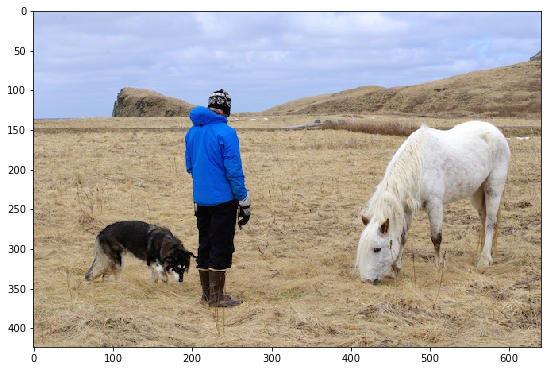

```python
img = cv2.imread('examples/person.jpg')
img = cv2.cvtColor(img, cv2.COLOR_BGR2RGB)
plt.figure(figsize = (20, 20))
plt.subplot(1, 2, 1); plt.imshow(img)
img.shape
```

```
(576, 768, 3)
```

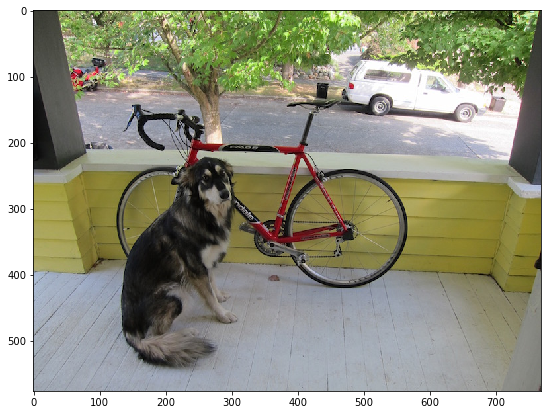

```python
img = cv2.imread('examples/dog.jpg')
img1 = cv2.cvtColor(img, cv2.COLOR_BGR2RGB)
plt.figure(figsize = (20, 20))
plt.subplot(1, 2, 1); plt.imshow(img1)
img1.shape
```

```
(360, 480, 3)
```

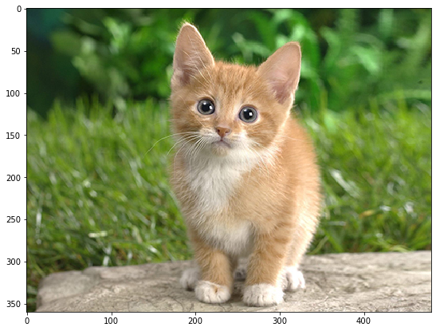

```python
img = cv2.imread('examples/cat.jpg')
img2 = cv2.cvtColor(img, cv2.COLOR_BGR2RGB)
plt.figure(figsize = (20, 20))
plt.subplot(1, 2, 1); plt.imshow(img2)
img2.shape
```

- 預測 Predictions

```python
%time
preds = model.predict(input_images, batch_size=1, verbose=1)
```

```
Wall time: 0 ns
```

- y_pred 每個批次項目
  - 包含固定數量的預測 -Default 模型配置 - 200
  - 許多 - 低置信度預測 Low- Confidence Predictions

    ```
     - 虛擬條目 Dummy Entries
    ```

  - 設定 信度閾值 ConfidenceThreshold Values
    - 濾除錯誤的預測

```python
y_pred = model.predict(input_images)
len(y_pred)
y_pred
```

```
array([[[  8.  ,   1.  ,  95.3 ,  12.05, 206.55, 287.1 ],
        [  0.  ,   0.  ,   0.  ,   0.  ,   0.  ,   0.  ],
        [  0.  ,   0.  ,   0.  ,   0.  ,   0.  ,   0.  ],
        ...,
        [  0.  ,   0.  ,   0.  ,   0.  ,   0.  ,   0.  ],
        [  0.  ,   0.  ,   0.  ,   0.  ,   0.  ,   0.  ],
        [  0.  ,   0.  ,   0.  ,   0.  ,   0.  ,   0.  ]]], dtype=float32)
```

```python
confidence_threshold = 0.5

y_pred_thresh = [y_pred[k][y_pred[k,:,1] > confidence_threshold] for k in range(y_pred.shape[0])]

np.set_printoptions(precision=2, suppress=True, linewidth=90)
print("Predicted boxes:\n")
print('   class   conf xmin   ymin   xmax   ymax')
print(y_pred_thresh[0])
```

```
Predicted boxes:

   class   conf xmin   ymin   xmax   ymax
[[  8.     1.    95.3   12.05 206.55 287.1 ]]
```

- 可視化 Visualize 預測結果
  - 調整 輸入圖片的大小 - Resized the input image above
  - 圖像進行預測
  - 可視化 Visualize 預測結果
    - 在 原始大小 圖片上顯示
  - 轉換 預測框 相應的坐標
- 繪製預測框 顯示在圖像上
  - 設置邊框的顏色 Bounding Boxes

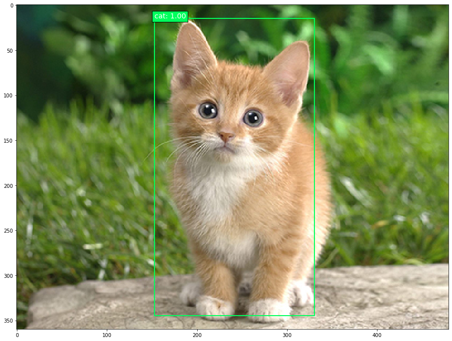

```python
colors = plt.cm.hsv(np.linspace(0, 1, 21)).tolist()
classes = ['background',
           'aeroplane', 'bicycle', 'bird', 'boat',
           'bottle', 'bus', 'car', 'cat',
           'chair', 'cow', 'diningtable', 'dog',
           'horse', 'motorbike', 'person', 'pottedplant',
           'sheep', 'sofa', 'train', 'tvmonitor']

plt.figure(figsize=(20,12))
plt.imshow(orig_images[0])

current_axis = plt.gca()

 # 原始大小 300x300  圖片上 顯示 轉換 預測框  相應的坐標 300x300

for box in y_pred_thresh[0]:

    xmin = box[2] * orig_images[0].shape[1] / img_width
    ymin = box[3] * orig_images[0].shape[0] / img_height
    xmax = box[4] * orig_images[0].shape[1] / img_width
    ymax = box[5] * orig_images[0].shape[0] / img_height
    color = colors[int(box[0])]
    label = '{}: {:.2f}'.format(classes[int(box[0])], box[1])
    current_axis.add_patch(plt.Rectangle((xmin, ymin), xmax-xmin, ymax-ymin, color=color, fill=False, linewidth=2))
    current_axis.text(xmin, ymin, label, size='x-large', color='white', bbox={'facecolor':color, 'alpha':1.0})
```

- Predictions - Pascal VOC 2007 Test
- 對Pascal VOC 2007測試做出預測
  - 使用 DataGenerator
    - 對Pascal VOC 2007 測試數據集 - 預測
    - 預測框 與 真實框 -可視化以進行比較
- 下載 VOC 2007 Datasets
  - https://pjreddie.com/projects/pascal-voc-dataset-mirror/
  - http://host.robots.ox.ac.uk/pascal/VOC/
  - http://host.robots.ox.ac.uk/pascal/VOC/voc2007/index.html
- Unzip
- VOC_2007_images_dir = 'datasets/VOCdevkit/VOC2007/JPEGImages/'
- VOC_2007_annotations_dir = 'datasets/VOCdevkit/VOC2007/Annotations/'
- VOC_2007_test_image_set_filename = 'datasets/VOCdevkit/VOC2007/ImageSets/Main/test.txt'
- 創建
  - BatchGenerator
- 解析 Pascal VOC 標籤
- 掉用 XML 解析器
  - 查找 - 對像類名稱

    ```
     - 映射到 整數 的順序
    ```

```python
%%time
# Create a `BatchGenerator` instance and parse the Pascal VOC labels.

dataset = DataGenerator()


VOC_2007_images_dir         = 'datasets/VOCdevkit/VOC2007/JPEGImages/'
VOC_2007_annotations_dir    = 'datasets/VOCdevkit/VOC2007/Annotations/'
VOC_2007_test_image_set_filename = 'datasets/VOCdevkit/VOC2007/ImageSets/Main/test.txt'

# The XML parser needs to now what object class names to look for and in which order to map them to integers.
classes = ['background',
           'aeroplane', 'bicycle', 'bird', 'boat',
           'bottle', 'bus', 'car', 'cat',
           'chair', 'cow', 'diningtable', 'dog',
           'horse', 'motorbike', 'person', 'pottedplant',
           'sheep', 'sofa', 'train', 'tvmonitor']

dataset.parse_xml(images_dirs=[VOC_2007_images_dir],
                  image_set_filenames=[VOC_2007_test_image_set_filename],
                  annotations_dirs=[VOC_2007_annotations_dir],
                  classes=classes,
                  include_classes='all',
                  exclude_truncated=False,
                  exclude_difficult=True,
                  ret=False)

convert_to_3_channels = ConvertTo3Channels()
resize = Resize(height=img_height, width=img_width)

generator = dataset.generate(batch_size=1,
                             shuffle=True,
                             transformations=[convert_to_3_channels,
                                              resize],
                             returns={'processed_images',
                                      'filenames',
                                      'inverse_transform',
                                      'original_images',
                                      'original_labels'},
                             keep_images_without_gt=False)
```

```
Wall time: 38.5 s
```

- 生成一個批次 量
  - 進行預測

```python
batch_images, batch_filenames, batch_inverse_transforms, batch_original_images, batch_original_labels = next(generator)

i = 0 # Which batch item to look at

print("Image:", batch_filenames[i])
print()
print("Ground truth boxes:\n")
print(np.array(batch_original_labels[i]))
```

```
Image: datasets/VOCdevkit/VOC2007/JPEGImages/007014.jpg

Ground truth boxes:

[[  7  29  63 428 359]]
```

- 預測 Predict

```python
y_pred = model.predict(batch_images)
```

- 可視化 Visualize 預測結果
  - 調整 輸入圖片的大小 - Resized the input image above
  - 圖像進行預測
  - 可視化 Visualize 預測結果
    - 在 原始大小 圖片上顯示
  - 轉換 預測框 相應的坐標

```python
confidence_threshold = 0.8

# Perform confidence thresholding.
y_pred_thresh = [y_pred[k][y_pred[k,:,1] > confidence_threshold] for k in range(y_pred.shape[0])]

# Convert the predictions for the original image.
y_pred_thresh_inv = apply_inverse_transforms(y_pred_thresh, batch_inverse_transforms)

np.set_printoptions(precision=2, suppress=True, linewidth=90)
print("Predicted boxes:\n")
print('   class   conf xmin   ymin   xmax   ymax')
print(y_pred_thresh_inv[i])
```

```
Predicted boxes:

   class   conf xmin   ymin   xmax   ymax
[[  7.   1.  17.  61. 425. 333.]]
```

- 繪製預測框 顯示在圖像上
  - 設置邊框的顏色 Bounding Boxes

[figure not shown]

```python
colors = plt.cm.hsv(np.linspace(0, 1, 21)).tolist()

plt.figure(figsize=(20,12))
plt.imshow(batch_original_images[i])

current_axis = plt.gca()

for box in batch_original_labels[i]:
    xmin = box[1]
    ymin = box[2]
    xmax = box[3]
    ymax = box[4]
    label = '{}'.format(classes[int(box[0])])
    current_axis.add_patch(plt.Rectangle((xmin, ymin), xmax-xmin, ymax-ymin, color='green', fill=False, linewidth=2))
    current_axis.text(xmin, ymin, label, size='x-large', color='white', bbox={'facecolor':'green', 'alpha':1.0})

for box in y_pred_thresh_inv[i]:
    xmin = box[2]
    ymin = box[3]
    xmax = box[4]
    ymax = box[5]
    color = colors[int(box[0])]
    label = '{}: {:.2f}'.format(classes[int(box[0])], box[1])
    current_axis.add_patch(plt.Rectangle((xmin, ymin), xmax-xmin, ymax-ymin, color=color, fill=False, linewidth=2))
    current_axis.text(xmin, ymin, label, size='x-large', color='white', bbox={'facecolor':color, 'alpha':1.0})
```